# Corporate Network Analysis

Author: Vincent Grunert

Date: 13 June 2022

## Executive Summary

This project analyzes a network of corporations, based on Twitter's publicly available data. First, a machine learning models is trained to predict whether or not an account belongs to a corporation. This model is then used to estimate whether or not user accounts belong to corporations or not. Second, five most influential corporations are being identified. Third, the network is divided into homogenous communities by comparing community detection algorithms. Fourth, the two previous results are combined to identify the most influential user in each community. Finally, associations of corporations and interest groups are discovered. There are two main associations: either corporations are affiliated to hashtags relating to innovation and technology or two holidays.

## Outline

This work is divided into four sections. First, the process of how the network data was obtained is described. Second, methods for the identification of influential users and the results are presented. Next, community detection algorithms are being compared and a model selection procedure is being applied. Finally, assistance of corporations and interest groups called hashtags on Twitter are discovered.

## Data

The goal of this study is to obtain an understanding of how corporations relate to each other. The Twitter API provides means to obtain such data. Twitter is a Social Media platform which allows users to publicly share information, called "tweets" and follow other users among many other things. For the purpose of this study, the goal is to identify which corporations are in realation to each other. Provided an account belongs to a corporation, the Twitter API allows to identify which other users this account follows. However, there is no indication whether or not this account belongs to a corporation or an individual or a corporation. Hence a model that estimates whether or not an account belongs to a corporation or not is required.

### Transformations

The numeric and boolean variables are left as they are and the nominal variables are transformed to boolean variables that take are "True" if there is an entry and "False" if there is not.

### Additions

The dataset was transformed by adding the boolean variable "Corporate", which takes the values "Corparate" if the account belongs to a known corporation, and "private" if it does not.

## Model

Classification models are used to predict dichotomous variables such as whether or not an account belongs to a corporation or not. Logistic regression is a popular linear classification model which is being described below.

### Logistic Regression

The goal is to predict whether or not a user account belongs to a corporation or not. Let $y_i = 1$ if the $i$'th users account belongs to a corpora $y_i = 0$ otherwise. Since $y_i$ can only take on two values, it can be considered as Bernoulli random variable $y_i \sim Ber(p_i)$ whose probability mass function is described by: $f(y_i) = p_i^{y_i}(1-p_i)^{1-y_i}$. Where $p_i$ is the probability of $y_i = 1$. Note that probabilities can only take on values between zero and one. The goal is to use the user data to estimate the unknown quantity $p_i$ by a linear combination of the user data $x_{i,j}:$ $\beta_1x_{i,1} + \beta_2x_{i,2} + ... + \beta_n x_{i,n} = X_i'\beta$. The key issue is $p_i$ can only take values between zero and one, however $X_i'\beta$ can take values between $\pm \infty$. Thus $p_i = X_i'\beta$ is not valid, since the two sides can take on different values. In order to meaningfully relate the two quantities we have to either place a restriction on the $\beta$'s, or to use a function that ensures that both $p_i$ and $X_i'\beta$ can take the same values. The latter approach works by using a "link" function:

$$ g(p_i) = log(\frac{p_i}{1-p_i}) = X_i'\beta $$

The name 'logistic' regression comes from using the logarithm of the odds ratio as the link function. The following plot show's why this approach works. It can be seen that for all values of $p$ between zero and one, the $log(\frac{p}{1-p})$ can take positives and negative values that would go to $\pm \infty$ if we make the intervals small enough. Thus, by using the log odds ratio, the goal of mapping the probabilities $p_i$ into the $X_i'\beta$ space has been achieved.

```python
import numpy as np
import matplotlib.pyplot as plt
import networkx as nx
from networkx.algorithms import bipartite
import pandas as pd
import sklearn as sk
from sklearn import metrics
from sklearn.linear_model import LogisticRegressionCV
from sklearn.model_selection import train_test_split
from scipy import sparse
from scipy.cluster.hierarchy import dendrogram
from sklearn.cluster import AgglomerativeClustering
from sklearn.cluster import KMeans
from sklearn.cluster import SpectralClustering
import json
```

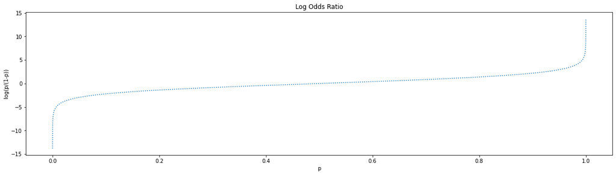

```python
# Probabilities can take values from 0 to 1. For p = 1 we have log (1/0) which is not defined
p = np.arange(0.000001, 1, step = 0.000001)

# log odds ratio for different values of p
log_odds = np.log(p/(1-p))

# plot log odds ratio
plt.figure(figsize=(20, 5))
plt.plot(p, log_odds, linestyle = 'dotted')
plt.title("Log Odds Ratio")
plt.xlabel("p")
plt.ylabel("log(p/(1-p))")
```

The likelihood of observing $n$ independent and identically distributed Bernoulli random variables is given by: $$ L(\beta) = \prod_{i = 1}^np_i^{y_i}(1-p_i)^{1-y_i} = p_i^{\sum_{i = 1}y_i}(1-p_i)^{\sum_{i = 1}(1-y_i)} = p_i^{\sum_{i = 1}y_i}(1-p_i)^{n - \sum_{i = 1}y_i} $$

Since it is easier to calculate with sums than with products, the logarithm of both sides of the equation and obtain is taken:

$$ \begin{align*} l(\beta) &= \sum_{i = 1}y_ilog(p_i) + (n - \sum_{i = 1}y_i)log(1-p_i) \\ &= \sum_{i = 1}y_ilog(p_i) + nlog(1-p_i) - \sum_{i = 1}y_ilog(1-p_i) \\ &= \sum_{i = 1}y_i(log(p_i)-log(1-p_i)) + nlog(1-p_i) \\ &= \sum_{i = 1}y_ilog(\frac{p_i}{1-p_i}) + nlog(1-p_i) \\ \end{align*} $$

This is where the equation $log(\frac{p_i}{1-p_i}) = X_i'\beta$ is used. Additionally, note that:

$$ \begin{align*} log(\frac{p_i}{1-p_i}) &= X_i'\beta \\ \Rightarrow \frac{p_i}{1-p_i} &= e^{X_i'\beta} \\ \Rightarrow \frac{1-p_i}{p_i} &= \frac{1}{e^{X_i'\beta}} \\ \Rightarrow \frac{1}{p_i} -1 &= \frac{1}{e^{X_i'\beta}} \\ \Rightarrow \frac{1}{p_i} &= 1 + \frac{1}{e^{X_i'\beta}} \\ \Rightarrow \frac{1}{p_i} &= \frac{e^{X_i'\beta}}{e^{X_i'\beta}} + \frac{1}{e^{X_i'\beta}} \\ \Rightarrow \frac{1}{p_i} &= \frac{e^{X_i'\beta} + 1}{e^{X_i'\beta}} \\ \Rightarrow p_i &= \frac{e^{X_i'\beta}}{e^{X_i'\beta} + 1} \\ \Rightarrow 1- p_i &= 1- \frac{e^{X_i'\beta}}{e^{X_i'\beta} + 1} \\ \Rightarrow 1- p_i &= \frac{e^{X_i'\beta} + 1}{e^{X_i'\beta} + 1}- \frac{e^{X_i'\beta}}{e^{X_i'\beta} + 1} \\ \Rightarrow 1- p_i &= \frac{1}{e^{X_i'\beta} + 1}\\ \end{align*} $$

Plugging these values into the log likelihood: $$ \begin{align*} l(\beta) &= \sum_{i = 1}y_ilog(\frac{p_i}{1-p_i}) + nlog(1-p_i) \\ &= \sum_{i = 1}y_iX_i'\beta + nlog(\frac{1}{e^{X_i'\beta} + 1}) \\ &= \sum_{i = 1}y_iX_i'\beta + n(log(1) - log(e^{X_i'\beta} + 1)\\ &= \sum_{i = 1}y_iX_i'\beta + n(0 - log(e^{X_i'\beta} + 1)\\ &= \sum_{i = 1}y_iX_i'\beta - nlog(e^{X_i'\beta} + 1)\\ \end{align*} $$

Thus all $p_i$ were replaced by a function of $X_i'\beta$, which we can calculate since we have the user data. Here the only unknown quantities are the $\beta$'s. Since the interest lies in which $\beta$'s make the observed quantities most likely, the next step is to maximise with respect to $\beta$ and set to zero:

$$ \begin{align*} \frac{d}{d\beta}l(\beta) &= \frac{d}{d\beta}(\sum_{i = 1}y_iX_i'\beta - nlog(e^{X_i'\beta} + 1)) \overset{!}{=} 0\\ \end{align*} $$

However, for this expression there exists no closed form solution, so numeric optimization algorithms are used to calculate the optimal $\beta$'s. Since $\sum_{i = 1}y_iX_i'\beta - nlog(e^{X_i'\beta} + 1)$ is a convex function (without proof), there exists a unique optimum. Hence it is guaranteed that it is possible to obtain the $\beta$'s that maximizes the likelihood of observing our data. In the following, the results of the estimation, including code are presented.

### Estimation

In order to estimate the model, the dataset is split in two disjoint parts. The first part, 70% of observations is used to estimate the model, while the remaining 30% are used to test the model's performance. Furthermore, tenfold cross-validation is being performed during the estimation process.

```python
# read data
# for privacy reasons we exclude the actual dataset

# coporations
y = trng_data['corporate']

# user data, remove nominal data and dependend variable
X = trng_data.loc[:, ~trng_data.columns.isin(['id', 'name', 'corporate'])]

# Split data in training and test set
X_train, X_test, y_train, y_test = train_test_split(X, y, test_size = 0.3)

# Perform logistic regression
LR = LogisticRegressionCV(solver='lbfgs', cv = 10, multi_class='ovr',  max_iter=10000).fit(X_train, y_train)
```

### Performance

```
<sklearn.metrics._plot.confusion_matrix.ConfusionMatrixDisplay at 0x7f63f8f079a0>
```

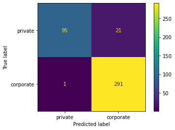

```python
# Predict test data
pred = LR.predict(X_test)

# Predicted probabilities
pred_prob = LR.predict_proba(X_test)

# Confusion Matrix
cm = metrics.confusion_matrix(np.where(y_test == 0, 'private', 'corporate'), np.where(pred == 0, 'private', 'corporate'))

disp = metrics.ConfusionMatrixDisplay(confusion_matrix=cm, display_labels = ['private', 'corporate'])
disp.plot()
```

Another performance measure is called the "Receiver-Operator-Curve" (ROC). The ROC relates the false-positive rate on the x-axis and the true-positive rate on the y-axis for all $\tau$ values ranging from $0-1$. We can see that the ROC has only one point at (0.00342466, 0.81896552). As a comparison the perfect classification is at (0, 1). Hence we conclude that the performs very well in the classification task.

```
No artists with labels found to put in legend.  Note that artists whose label start with an underscore are ignored when legend() is called with no argument.
```

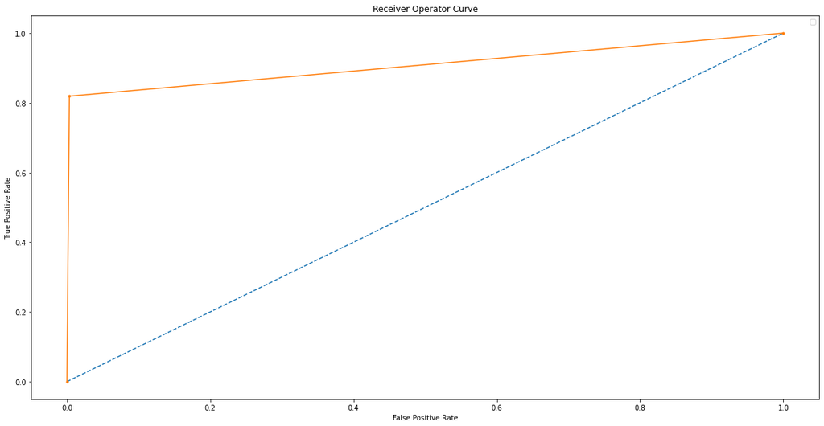

```python
# Calculating the ROC
preds = pred_prob[:,1]
fpr, tpr, threshold = metrics.roc_curve(y_test, preds)
roc_auc = metrics.auc(fpr, tpr)

ns_probs = [0 for _ in range(len(y_test))]
ns_auc = metrics.roc_auc_score(y_test, ns_probs)
lr_auc = metrics.roc_auc_score(y_test, preds)

ns_fpr, ns_tpr, _ = metrics.roc_curve(y_test, ns_probs)
lr_fpr, lr_tpr, _ = metrics.roc_curve(y_test, pred)

# method I: plt
plt.figure(figsize = (20,10))
plt.title('Receiver Operator Curve')
plt.xlabel('False Positive Rate')
plt.ylabel('True Positive Rate')
# show the legend
plt.legend()
plt.plot(ns_fpr, ns_tpr, linestyle='--', label='No Skill')
plt.plot(lr_fpr, lr_tpr, marker='.', label='Logistic')
# axis labels
# show the plot
```

### Application

The trained an evaluated model can applied to create the network of corporations. First, all the accounts that a particular corporation follows are obtained. These are called 'friends' of the corporation. For the 'friends' the model is used to classify them as corporations or private. Only corporations are kept. Thus the relations from one corporation to possibly many others is obtained. This process is repeated to finally obtain the final network.

## Corporate Network Analysis

There exists a mathematical theory called Graph Theory, which is concerned about analysing and drawing inference about relating objects. This theory is well developed and some of its results are used to describe, analyse and draw inference about the relationships among the corporations in the data set.

### Notation

In the following, the terms graph and network will be used equivalently. Mathematically, a graph is a set of vertices (nodes) $\mathcal{N} =\{n_1, ..., n_k\}$ and lines (edges) $\mathcal{L} = \{l_1,...,l_g\}$ between a pair of nodes, for example $l_j = (n_1, n_2)$. Thus a graph $\mathcal{G}$ is described by its nodes and lines between those nodes, hence: $\mathcal{G} = \{\mathcal{N}, \mathcal{L}\}$. In the example, nodes are the corporations and the edges refer to which corporations have befriended which. The corporation dataset is called a directed graph, meaning that a befriending does not have to be mutual. For example corporation A might follow corporation B but not vice versus.

```python
# Read network data
# same as above

# Create di-graph object
G = nx.from_pandas_edgelist(corp_network, source= 'from', target = 'to', create_using=nx.DiGraph)
```

```python
nx.info(G)
```

```
'DiGraph with 111616 nodes and 152971 edges'
```

### Description

The graph has a total of 111616 nodes and 152971 edges. One of the key properties is the degree of a node. For a directed graph there is a distinction between in- and outdegree ($d_I (n_i), d_O (n_i) $). Indegree is the number of connections coming into a node, meaning how many other corporations choose to follow it. It is an indicator of popularity, since a large indegree means that many other corporations choose to follow this one. The outdegree refers to the amount connections going out from a node. In the example it would be which other corporations a particular corporation follows.

```python
indegrees = G.in_degree()
indegr = []

for usr, deg in indegrees:
    indegr.append([usr, deg])

indegree_df = pd.DataFrame(indegr, columns=['User', 'Indegree'])
indegree_df['Indegree'].describe()
```

```
count    111616.000000
mean          1.370511
std           1.584549
min           0.000000
25%           1.000000
50%           1.000000
75%           1.000000
max          92.000000
Name: Indegree, dtype: float64
```

The following graph shows the histogram of the indegree values. Note that the y-axis is scaled logarithmically, in order to make the results readable. It can be seen that the vast amount of nodes has few (10 or less) incoming connections and then we observe an exponential decay. There are two nodes with an indegree of 80 or more, indicating that there are only very few "popular" nodes.

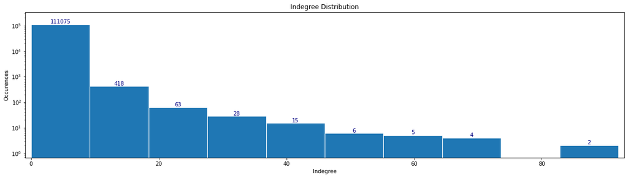

```python
plt.figure(figsize=(20, 5))
values, bins, bars = plt.hist(indegree_df['Indegree'], edgecolor='white', log = True)
plt.title("Indegree Distribution")
plt.xlabel("Indegree")
plt.ylabel("Occurences")
plt.bar_label(bars, fontsize=10, color='navy')
plt.margins(x=0.01, y=0.1)
plt.show()
```

```python
outdegrees = G.out_degree()
outdegr = []

for usr, deg in outdegrees:
    outdegr.append([usr, deg])

outdegree_df = pd.DataFrame(outdegr, columns=['User', 'Outdegree'])
outdegree_df['Outdegree'].describe()
```

```
count    111616.000000
mean          1.370511
std          29.898835
min           0.000000
25%           0.000000
50%           0.000000
75%           0.000000
max         948.000000
Name: Outdegree, dtype: float64
```

Note that the mean of the outdegree is the same of the indegree. This results from the fact that every outgoing node is another node incoming so in total the numbers should be the same. Which can easily verified:

```python
print("Sum Indegree: ", np.sum(indegree_df['Indegree']), " sum outdegree: ", np.sum(outdegree_df['Outdegree']), " both equal? ", np.sum(indegree_df['Indegree']) == np.sum(outdegree_df['Outdegree']))
```

```
Sum Indegree:  152971  sum outdegree:  152971  both equal?  True
```

Thus the sum of integrals equals the sum of outdegrees and thus the means are also equal. The following graph shows the histogram of the outdegree values. Again, the y-axis is scaled logarithmically, in order to make the results readable. It can be seen that 111340 nodes have an outdoor of 100 or less. The remaining nodes are approximately uniformly distributed to approximately 900. Thus there is a difference in the estimated indegree and distribution. This indicates that it is more likely that a node emits more connections then it receives.

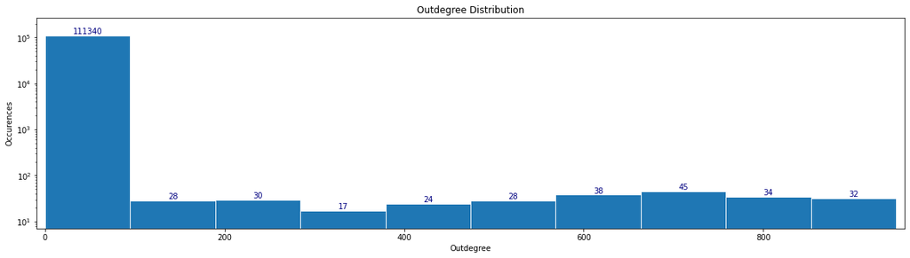

```python
plt.figure(figsize=(20, 5))
values, bins, bars = plt.hist(outdegree_df['Outdegree'], edgecolor='white', log = True)
plt.title("Outdegree Distribution")
plt.xlabel("Outdegree")
plt.ylabel("Occurences")
plt.bar_label(bars, fontsize=10, color='navy')
plt.margins(x=0.01, y=0.1)
```

The density of a graph is the number of arcs relative to the total number of possible arcs. If there are a total number of $g$ arcs in a directed, then there is a total amount of $g(g-1)$ possible arcs. Thus, then density measures the actual- relative to the possible amount of arcs in a graph. A dense graph should have a value close to 1. In our case the density is:

```python
np.sum(indegree_df['Indegree']) / (G.number_of_nodes()*(G.number_of_nodes()-1))
```

```
1.2278917674287473e-05
```

which is rather low.

For directed graphs we can distinguish between four different types of nodes:

- Isolate: $d_I(n_i) = d_O(n_i) = 0$ meaning the indegree equals the outdegree equals to zero
- Transmitter: $d_I(n_i) = 0 \text{ and } d_O(n_i) > 0$
- Receiver: $d_I(n_i) > 0 \text{ and } d_O(n_i) = 0$
- Carrier / Ordinary: $d_I(n_i) > 0 \text{ and } d_O(n_i) > 0$

```python
Isolate = pd.merge(indegree_df[indegree_df['Indegree'] == 0], outdegree_df[outdegree_df['Outdegree'] == 0], on = ["User"])
Isolate
```

|  | User | Indegree | Outdegree |
| --- | --- | --- | --- |

```python
Transmitter = pd.merge(indegree_df[indegree_df['Indegree'] == 0], outdegree_df[outdegree_df['Outdegree'] > 0], on = ["User"])
Transmitter.iloc[:,1:3].sort_values(by=['Outdegree'], ascending=False)
```

|  | Indegree | Outdegree |
| --- | --- | --- |
| 26 | 0 | 889 |
| 17 | 0 | 888 |
| 1 | 0 | 882 |
| 15 | 0 | 860 |
| 6 | 0 | 854 |
| ... | ... | ... |
| 63 | 0 | 1 |
| 78 | 0 | 1 |
| 16 | 0 | 1 |
| 3 | 0 | 1 |
| 81 | 0 | 1 |

82 rows × 2 columns

```python
Receiver = pd.merge(indegree_df[indegree_df['Indegree'] > 0], outdegree_df[outdegree_df['Outdegree'] == 0], on = ["User"])
Receiver.iloc[:,1:3].sort_values(by=['Indegree'], ascending=False)
```

|  | Indegree | Outdegree |
| --- | --- | --- |
| 2104 | 92 | 0 |
| 1907 | 87 | 0 |
| 2102 | 72 | 0 |
| 834 | 72 | 0 |
| 2105 | 65 | 0 |
| ... | ... | ... |
| 45693 | 1 | 0 |
| 45692 | 1 | 0 |
| 45690 | 1 | 0 |
| 45689 | 1 | 0 |
| 111303 | 1 | 0 |

111304 rows × 2 columns

```python
Receiver_ones = pd.merge(indegree_df[indegree_df['Indegree'] == 1], outdegree_df[outdegree_df['Outdegree'] == 0], on = ["User"])
Receiver_ones.iloc[:,1:3]
```

|  | Indegree | Outdegree |
| --- | --- | --- |
| 0 | 1 | 0 |
| 1 | 1 | 0 |
| 2 | 1 | 0 |
| 3 | 1 | 0 |
| 4 | 1 | 0 |
| ... | ... | ... |
| 92871 | 1 | 0 |
| 92872 | 1 | 0 |
| 92873 | 1 | 0 |
| 92874 | 1 | 0 |
| 92875 | 1 | 0 |

92876 rows × 2 columns

```python
Carrier = pd.merge(indegree_df[indegree_df['Indegree'] > 0], outdegree_df[outdegree_df['Outdegree'] > 0], on = ["User"])
Carrier.iloc[:,1:3].sort_values(by=['Outdegree'], ascending=False)
```

|  | Indegree | Outdegree |
| --- | --- | --- |
| 28 | 7 | 948 |
| 36 | 7 | 939 |
| 91 | 2 | 939 |
| 187 | 2 | 933 |
| 83 | 3 | 925 |
| ... | ... | ... |
| 136 | 3 | 13 |
| 60 | 10 | 10 |
| 57 | 4 | 3 |
| 174 | 2 | 1 |
| 88 | 1 | 1 |

230 rows × 2 columns

There are no isolated-, 82 transmitter-, 111304 receiver- with 92876 of indegree of 1 and 230 carrier nodes. Thus by far most nodes are receiver nodes.

## Distances

So far information about unidirectional relations among the corporations was gathered. Some corporations are connected directly to each other, others are not. For those who are not directly connected, the question remains if it is possible to reach that corporation indirectly via other's and if yes in how many steps. The solution to these questions can be found by having understanding of how the graph is stored internally. There are different ways to store and represent a graph, but an intuitive one is called the adjacency matrix. Essentially, it is a square matrix where each row and column represents a node. If corporation $i$ follows corporation $j$ then the matrix has a one at the index $i,j$. Now if corporation $j$ follows corporation $k$ then there exists an indirect relationship: $i \rightarrow j \rightarrow k$. This connection is called a path and its distance would be 2. It can be shown that the nth power of the adjacency matrix contains all paths of length $n$, where $n < (g-1)$. Furthermore, adding $R = A^1 + A^2 + ... + A^{g-1}$ returns what is called the reachability matrix. The following example will clarify these ideas.

The following graph shows that there are three paths of length two: $0 \rightarrow 1 \rightarrow 2$ and $0 \rightarrow 1 \rightarrow 3$ and $1 \rightarrow 2 \rightarrow 3$ and one path of length three: $0 \rightarrow 1 \rightarrow 2 \rightarrow 3$.

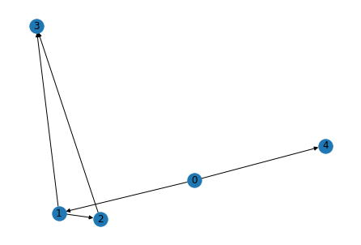

```python
test = np.array([[0,1,0,0, 1], [0,0,1,1,0],[0,0,0,1,0],[0,0,0,0,0],[0,0,0,0,0]])
test_graph = nx.from_numpy_array(test, create_using=nx.DiGraph)
test_adj = nx.adjacency_matrix(test_graph)
pow_1 = test_adj.todense()
pow_2 = pow_1.dot(pow_1)
pow_2_graph = nx.from_numpy_array(pow_2, create_using=nx.DiGraph)
pow_3 = test_adj.dot(pow_2)
pow_3_graph = nx.from_numpy_array(pow_3, create_using=nx.DiGraph)
reachability = pow_1 + pow_2 + pow_3
reachability = nx.from_numpy_array(reachability, create_using=nx.DiGraph)
nx.draw(test_graph, with_labels = True)
```

The following graph shows the second power of the graph which contains all paths of length two. There are three in total which is exactly what was initially observed.

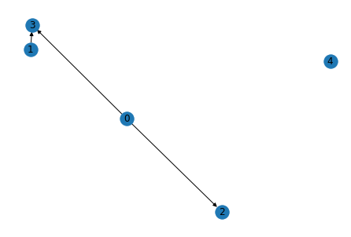

```python
nx.draw(pow_2_graph, with_labels = True)
```

The following graph shows the third power of the graph. There is exactly one path of length three: $0 \rightarrow 3$.

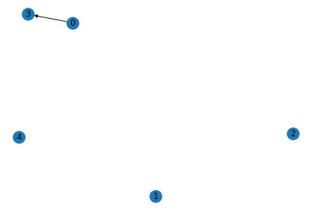

```python
nx.draw(pow_3_graph, with_labels = True)
```

The following graph visualizes the reachability matrix, which was obtained by adding all the previous powers together.

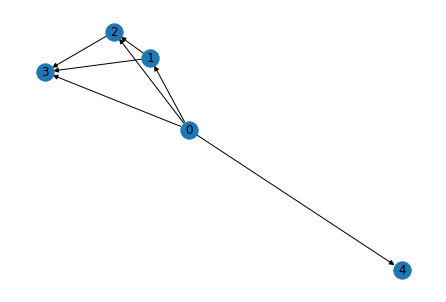

```python
nx.draw(reachability, with_labels = True)
```

In the following the same methodology is applied to answer related questions about the corporate network. For example, is possible to reach corporation 251 from corporation 5 in 5 steps?

```python
# Adjencency matrix of graph
A = nx.adjacency_matrix(G)
# B = np.dot(A, A)
B = A
power = 1
while B[5, 251] == 0:
    B = np.dot(A, B)
    power += 1
    if power == 6:
        print("Have not been able to reach corporation in 5 steps")
        break
# power
```

```
Have not been able to reach corporation in 5 steps
```

The following code calculates the number of paths of length $1,2,...,n$.

```python
res = {}
res[0] = sparse.csr_matrix.count_nonzero(A)
temp = 1
for i in range(1, 100):
    temp = np.dot(A, temp)
    res[i] = sparse.csr_matrix.count_nonzero(temp)
```

```python
pd.DataFrame.from_dict(res, orient = 'index')
```

|  | 0 |
| --- | --- |
| 0 | 152971 |
| 1 | 152971 |
| 2 | 490049 |
| 3 | 1348141 |
| 4 | 2912922 |
| ... | ... |
| 95 | 13848833 |
| 96 | 13848071 |
| 97 | 13848833 |
| 98 | 13848071 |
| 99 | 13848833 |

100 rows × 1 columns

The values 13848071, 13848833 start to repeatedly iterate, which implies that there is a circle somewhere in the graph. A circle is a walk $i \rightarrow j \rightarrow k \rightarrow i$, meaning that one ends up where one began.

## Prominence

The following section discusses different approsches to identify the importance or prominence of a particular node within a network. There are two main concepts. The first is called centrality and the second prestige. Centrality is concerned with "choices made" and prestige with "choices received".

### Centrality

There are two main indicies that measure centrality: degree and closeness centrality.

#### Degree centrality

Degree centrality is defined as: $$ C_d(n_i) := \frac{d_O(n_i)}{g-1} $$

where $g$ is the total number of nodes in the network. For the corporation dataset, the following users have the highest degree centrality index:

```python
C_D = nx.out_degree_centrality(G)
C_D_df = pd.DataFrame.from_dict(C_D,orient='index')
C_D_df.sort_values(by = list(C_D_df.columns), ascending=False)
```

|  | 0 |
| --- | --- |
| 274673392 | 0.008493 |
| 204491797 | 0.008413 |
| 35961145 | 0.008413 |
| 103637045 | 0.008359 |
| 32166535 | 0.008287 |
| ... | ... |
| 3063920961 | 0.000000 |
| 896057234 | 0.000000 |
| 85562366 | 0.000000 |
| 75094908 | 0.000000 |
| 14523097 | 0.000000 |

111616 rows × 1 columns

#### Closeness centrality

Closeness centrality is defined as: $$ C_c(n_i) := \frac{g-1}{\sum_{j=1}^g d(n_i, n_j)} $$

where $g$ is the total number of nodes in the network and $d$ is the shortest path between node $i$ and $j$. For the corporation dataset the following users have the highest closeness centrality index:

```python
C_C = nx.closeness_centrality(G, wf_improved=True)
C_C_df = pd.DataFrame.from_dict(C_C,orient='index')
C_C_df.sort_values(by = list(C_C_df.columns), ascending=False)
```

|  | 0 |
| --- | --- |
| 3108351 | 0.000988 |
| 91478624 | 0.000948 |
| 25053299 | 0.000905 |
| 21323268 | 0.000856 |
| 807095 | 0.000848 |
| ... | ... |
| 40929570 | 0.000000 |
| 10673252 | 0.000000 |
| 48402711 | 0.000000 |
| 839233893316251648 | 0.000000 |
| 773845041685139456 | 0.000000 |

111616 rows × 1 columns

### Prestige

There are several measures of prestige, among which the following two are being described:

- Degree-,
- Status / Rank prestige.

#### Degree Prestige

The degree prestige is measured by:

$$ P_D(n_i) = \frac{d_I(n_i)}{g-1} $$

It is essentially the weighted indegree of a node.

```python
P_D = nx.in_degree_centrality(G)
P_D_df = pd.DataFrame.from_dict(P_D,orient='index')
P_D_df.sort_values(by = list(P_D_df.columns), ascending=False)
```

|  | 0 |
| --- | --- |
| 3108351 | 0.000824 |
| 91478624 | 0.000779 |
| 25053299 | 0.000645 |
| 807095 | 0.000645 |
| 17093617 | 0.000582 |
| ... | ... |
| 40929570 | 0.000000 |
| 849979362 | 0.000000 |
| 2588219916 | 0.000000 |
| 426512056 | 0.000000 |
| 773845041685139456 | 0.000000 |

111616 rows × 1 columns

#### Status / Rank Prestige

The idea behind the status / rank prestige is that the prestige of a particular node depends on the importance of the other nodes "choosing" it. A simple way to describe this relationship would be to say that the prestige of node $i$ is a linear combination of all the other nodes, thus:

$$ P_R(n_i) = X_i'P_R \Rightarrow P_R - X_i'P_R = 0 \Rightarrow (I - X_i)'P_R = 0 $$

which is the solution to an eigenvalue problem ($\lambda p = X' p$) where $\lambda = 1$. However, it is not guaranteed that there exists such an eigenvalue. If we are able to put constraints on $X'$ such that there exists such an eigenvalue, then this would solve the problem. This is the basic idea behind the eigenvalue and Katz prestige.

```python
P_R_ev = nx.eigenvector_centrality_numpy(G)
P_R_ev_df = pd.DataFrame.from_dict(P_R_ev,orient='index')
sorted_ev_centr = P_R_ev_df.sort_values(by = list(P_R_ev_df.columns), ascending=False)
sorted_ev_centr
```

|  | 0 |
| --- | --- |
| 91478624 | 8.468906e-02 |
| 3108351 | 7.424254e-02 |
| 25053299 | 6.771375e-02 |
| 21323268 | 6.391218e-02 |
| 816653 | 6.338149e-02 |
| ... | ... |
| 64603054 | -2.628365e-18 |
| 35872799 | -2.653112e-18 |
| 234826866 | -2.825479e-18 |
| 140869994 | -2.840999e-18 |
| 139478841 | -2.901318e-18 |

111616 rows × 1 columns

Another closely related to the eigenvector centrality index is the Katz centrality.

```python
P_R_k = nx.katz_centrality(G)
P_R_k_df = pd.DataFrame.from_dict(P_R_k,orient='index')
P_R_k_df.sort_values(by = list(P_R_k_df.columns), ascending=False)
```

|  | 0 |
| --- | --- |
| 91478624 | 0.034587 |
| 3108351 | 0.034228 |
| 25053299 | 0.028998 |
| 807095 | 0.026655 |
| 21323268 | 0.026188 |
| ... | ... |
| 1934702336 | 0.002422 |
| 22551860 | 0.002422 |
| 74524430 | 0.002422 |
| 360018897 | 0.002422 |
| 773845041685139456 | 0.002422 |

111616 rows × 1 columns

### Conclusion

This section presented different approaches to detect influential individuals within a network. The nodes: 3108351, 91478624, 25053299, 21323268, 807095 appear on top of different influence measures which leads to the conclusion that there is indeed a group of influential corporations in the corporations dataset. Having detected influential users, the next step consists of separating the entire network into smaller cohesive communities.

## Community Detection

In the broadest sense, communities are groups that share certain similarities. To translate this idea into the graph theoretic domain, communities can be interpreted as nodes that share common properties and/or play similar roles in a graph. Community detection is applied in a wide range of applications such as detection of political opinion groups, customer segmentation, smart- and targeted advertisement and recommendation systems among many other fields and applications. In the following two different approaches to solve community detection problem are being discussed: local- and vertex similarity based. Note that most community detection algorithms are defined for undirected graphs. For directed graphs there are various ways to "undirect" them. One intuitive approach is to discard all connections that are not mutual, hence if $A$ is the adjacency matrix, then $A_R[i,j] = 1 \text{ if } A[i,j] = A[j,i]$ or else $A_R[i,j] = 0$. This approach is also known as recursively connected. The second approach is less stringent. A mutual connection is created if there exists a connection in either direction, thus: $A_W = 1 \text{ if } A[i,j] = 1 \text{ or } A[j,i] = 1$ and $A_W[i,j] = 0$ else. Originally we have:

```python
print(G.number_of_nodes(), G.number_of_edges())
```

```
111616 152971
```

The size of the graph is too large for standard algorithms, so it will be trimmed down by keeping the first 500 most important nodes as classified by the eigenvector centrality. This produces the following subgraph with:

```python
G_cp = G.copy()
d_in  = G_cp.in_degree()
d_out = G_cp.out_degree()
remove_nodes = []
for n in G_cp:
    # print(d_out[n])
    if d_in[n] == 1 and d_out[n] == 0:
        remove_nodes.append(n)

G_cp.remove_nodes_from(sorted_ev_centr.index[500:])
print(G_cp.number_of_nodes(), G_cp.number_of_edges())
```

```
500 1184
```

500 nodes and 1184 edges. For the recursively connected graph there are:

```python
G_R = G_cp.to_undirected(reciprocal = True)
G_R.number_of_edges()
```

```
7
```

and for the weakly connected graph there are:

```python
G_W = G_cp.to_undirected()
G_W.number_of_edges()
```

```
1177
```

edges. Thus, for the recursive connection there are 7, while it for the weak connection there are 1177 edges.

#### Local Similarities

Local similarity characterizations, use local properties of the nodes in order to detect communities. There are four main properties:

- mutuality of ties,
- closeness or reachability,
- frequency of ties and
- relative frequency of ties within members compared to non-members.

In order to discuss various approaches for local community detection, some characteristics of a (sub-) graph need to be defined. Two nodes are $adjacent$ if they are connected by a line. A graph is called:

- $complete$, if all nodes are adjacent to each other and
- $connected$, if there is a path between each pair of nodes

and a subgraph is called $maximal$ with respect to any property if it holds for the subgraph but not if any other node is being added. A $component$ is a maximal connected subgraph. The existence of two components in a graph implies that the graph is disconnected since there does not exist a path between the two components (by definition), hence not all nodes are reachable from all nodes.

##### Cliques

A clique is a set of nodes where each node is adjacent to each other. In other words cliques are maximal complete subgraphs of size $ \geq 3$. The issue with this definition of a community is that it is very strict: if all nodes are connected to each other except for one pair, it would not be a clique anymore. This implies that it is unlikely to extract many interesting large cliques to be analyzed from a network.

```python
clique_GR = nx.find_cliques(G_R)
[cl for cl in list(clique_GR) if len(cl) > 2]
```

```
[]
```

```python
nx.graph_clique_number(G_W)
```

```
4
```

#### Vertex Similarity

Methods based on vertex similarity group together vertices with similar behaviour. Due to the absence of a dependent variable, these are essentially unsupervised learning models. Classical techniques for unsupervised learning problems include hierarchical- and spectral clustering and k-means among others. In order to compare different models there exists a measure called modularity. Modularity will be used as a model selection criterion.

```python
A_GW = nx.adjacency_matrix(G_W).todense()
# A_GR = nx.adjacency_matrix(G_R).todense()
# Model estimation:
cluster = AgglomerativeClustering(n_clusters=5, affinity='euclidean', linkage='ward')
cluster_lables = cluster.fit_predict(A_GW)
kmeans_gw = KMeans(n_clusters=5, random_state=0).fit(A_GW)
sc_gr = SpectralClustering(5, affinity='precomputed', n_init=100, assign_labels='discretize')
sc_gr_gw = sc_gr.fit_predict(A_GW)
```

```python
# Store communities for model selection:
hierarch_communities = [[],[],[],[],[]]
kmeas_communities = [[],[],[],[],[]]
spectral_communities = [[],[],[],[],[]]
for ind, node in enumerate(G_W.nodes()):
    hierarch_communities[cluster_lables[ind]].append(node)
    kmeas_communities[kmeans_gw.labels_[ind]].append(node)
    spectral_communities[sc_gr.labels_[ind]].append(node)
```

##### Model Selection

Previously three different unsupervised community detection techniques were applied to the corporate network. Next the models are compared by their modularity.

```python
print(nx.community.modularity(G_W, hierarch_communities), nx.community.modularity(G_W, kmeas_communities), nx.community.modularity(G_W, spectral_communities))
```

```
-0.18253317443004516 0.030615832051447703 0.45139493939706743
```

Spectral clustering has the highest modularity value which is the model selection criterion.

### Application

Thus far two separate goals have been achieved. First, influential users were detected and second the network was partitioned according to the spectral clustering algorithm. While being interesting results in their own rights, combining the two results provides the means to effectively optimize strategies to influence communities. The most obvious choice would be to separate communities and then to pick the most influential user in that group in order to advance a desired goal. The following output findes the most influential user in the respective community.

```python
influential_users = {}
for ind, community in enumerate(spectral_communities):
    most_influential = 0
    temp = 0
    for usr in community:
        # print(sorted_ev_centr.loc[usr] > 0.1)
        if sorted_ev_centr.loc[usr][0] > temp:
            temp = sorted_ev_centr.loc[usr][0]
            most_influential = usr
    influential_users[ind] = {'usr':most_influential, 'value': temp}
pd.DataFrame.from_dict(influential_users, orient='index')
```

|  | usr | value |
| --- | --- | --- |
| 0 | 25053299 | 0.067714 |
| 1 | 91478624 | 0.084689 |
| 2 | 3108351 | 0.074243 |
| 3 | 21323268 | 0.063912 |
| 4 | 14885549 | 0.040585 |

## Affiliation Networks

So far only relations among the corporations were analyzed. A different perspective, is to look at how these corporations relate to interest groups. One way this can be achieved is by looking at affiliations of the corporations to groups. Twitter makes this process rather simple through the existence of hashtags.

Hashtags are essentially public folders which can be created by adding the "#" in front of a symbol. By adding a particular hashtag such as "#halloworld" to a tweet links it automatically to that public folder and displays the tweet there. This allows users to link their tweets to the same hashtag and form groups. This feature will be used to investigate if corporations have similar interests.

To obtain the hashtags for each user, 100 Tweets for each corporation in the network was downloaded. From these tweets the hashtags were extracted. In total there are 7302 unique hashtags. Hence, each corporation is linked to a set of hashtags, which can be represented as a graph.

The particularity of this graph is that all connections between corporations are ignored and the focus is only on the connection between corporations and hashtags. Graphs of this nature are called bipartite graphs.

### Properties

The first step in analyzing affiliation network is to start with the properties of the corporations and hashtags.

```python
# returns JSON object as

# a dictionary
hashtags = json.load(f)

# Closing file
f.close()

all_hashtags = []
for hashtag in hashtags:
    all_hashtags.extend(hashtags[hashtag])
len(np.unique(all_hashtags))

BG = nx.Graph()
BG.add_nodes_from(hashtags.keys(), bipartite=0)
BG.add_nodes_from(np.unique(all_hashtags), bipartite=1)
for usr in hashtags:
    for item in hashtags[usr]:
        BG.add_edges_from([(usr, item)])
top_nodes = {n for n, d in BG.nodes(data=True) if d["bipartite"] == 0}
bottom_nodes = set(BG) - top_nodes

BA = bipartite.biadjacency_matrix(BG, top_nodes, bottom_nodes).todense()
# BA_t = np.transpose(BA)
g, h = BA.shape
A = pd.DataFrame(BA, index = top_nodes, columns = bottom_nodes)
```

##### Corporations

There 307 corporations in total. A corporation is linked on averages to 32 hashtags, where 75% are linked to 46 hashtags or less.

```python
A.sum(axis = 1).describe()
```

```
count    307.000000
mean      32.775244
std       34.098257
min        0.000000
25%        7.000000
50%       22.000000
75%       46.000000
max      245.000000
dtype: float64
```

The following plot visualizes the summary statistics. The red line represents the median and the vertical grey line is the mean. The points in the boxplot can be considered outliers. From the boxplot it can be deduced that most corporations are linked to 100 or less hashtags.

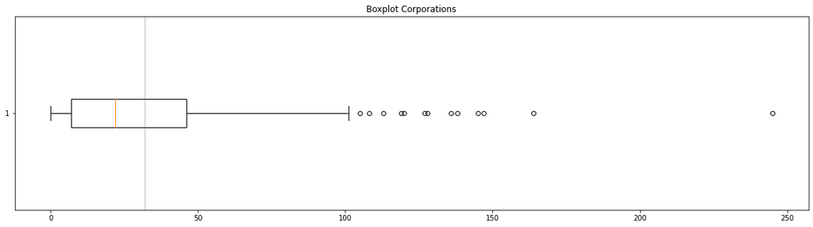

```python
plt.figure(figsize= [20,5])
plt.title("Boxplot Corporations")
plt.boxplot(A.sum(axis = 1), vert = False)
plt.axvline(32,  color = 'black', linewidth = 0.3)
```

The following plot shows the histogram of the degree distribution of the corporations. There is an exponential decline in the participation of corporations at different hashtags, meaning that most corporations tend to be affiliated with less than 50 hashtags.

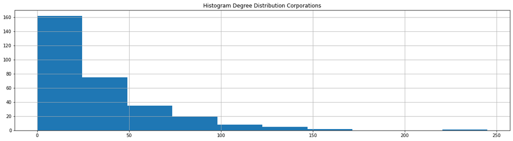

```python
plt.figure(figsize= [20,5])
plt.title("Histogram Degree Distribution Corporations")
A.sum(axis=1).hist()
```

#### Hashtags

There are 7302 hashtags in total. Of these, 75% have 1 corportion linked to it. The average hashtag is linked to 1.3 corporations.

```python
A.sum(axis = 0).describe()
```

```
count    7302.000000
mean        1.377979
std         2.214642
min         1.000000
25%         1.000000
50%         1.000000
75%         1.000000
max        77.000000
dtype: float64
```

The boxplot shows that the "box" is not present, which is a result from almost all values being equal to 1. Furthermore the presence of many outliers can be observed.

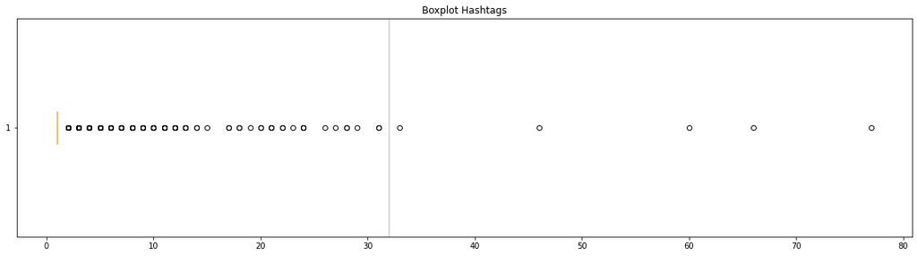

```python
plt.figure(figsize= [20,5])
plt.title("Boxplot Hashtags")
plt.boxplot(A.sum(axis = 0), vert = False)
plt.axvline(32,  color = 'black', linewidth = 0.3)
```

The histogram shows an exponential decline in the number of hashtags affiliated to users.

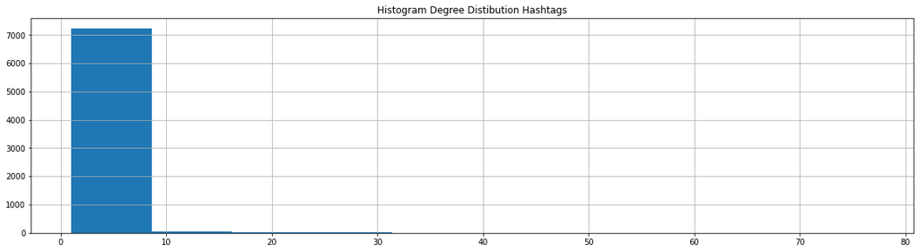

```python
plt.figure(figsize= [20,5])
plt.title("Histogram Degree Distibution Hashtags")
A.sum(axis=0).hist()
```

#### Correspondance Analysis

The basic idea behind correspondence analysis is to find similarities in different groups. To achieve this goal, first the data is turned into proportions. This can achieve by subtracting the sum of all values from each observation. Next, these proportions should be expressed in terms of opposing directions. This can be achieved by subtracting the expected value from each observation. Thus, each value is either greater or smaller than the respective expected value. Hence the data is expressed in terms of opposing signs. This result is called the residual matrix. Finally, dividing the residual matrix by the expected proportions, a nice interpretation is obtained: a particular value is the relative difference from the expected value in percent. For the actual calculations, the variation in the data should be smoothed out by dividing the residual matrix by the square root of the expected values. This will be called the standardized residual matrix. Next, a singular value decomposition (SVD) is performed on the standardized residual matrix. SVD reduces the data to a lower dimensional space while capturing the maximum amount of variation within the data. In particular, by choosing the first two components of the singular value decomposition the data is effectively reduced to two dimensions, which allows to plot and thus draw inference from our data. The following is a simple example to explain these ideas. Note that each row in the following matrix represents an observation and a columns a category.

```python
# data
X = np.array([
    [5,7,2],
    [18,46,20],
    [19,29,39],
    [12,40,49],
    [3,7,16]])
nrow, ncol = X.shape
```

The following lines of code present all calculations needed to express the data transformation:

```python
P = X/np.sum(X)
rp_sum = P.dot(np.repeat(1,ncol))
cp_sum = P.T.dot(np.repeat(1,nrow))
E = np.outer(rp_sum, cp_sum)
R = P - E
D_r = np.diag(1/np.sqrt(rp_sum))
D_c = np.diag(1/np.sqrt(cp_sum))
```

Indexed residuals: the first value in the top left corner of the matrix can be interpreted to be 95% more likely to be in the first category than expected.

```python
I = R / E
I
```

```
array([[ 0.95488722,  0.20930233, -0.6462585 ],
       [ 0.17293233,  0.32447398, -0.41043084],
       [ 0.1954023 , -0.19379845,  0.11001642],
       [-0.34966128, -0.04213677,  0.20132013],
       [-0.36842105, -0.34883721,  0.52380952]])
```

By dividing through the square root of the expected values rather than the expected values essentially takes out a part of the variation caused through sampling errors.

```python
R / np.sqrt(E)
```

```
array([[ 0.08645676,  0.02850876, -0.08699634],
       [ 0.03835294,  0.10825794, -0.13533506],
       [ 0.04410341, -0.06580368,  0.03691882],
       [-0.0850337 , -0.01541566,  0.07279115],
       [-0.04545838, -0.06475149,  0.09609278]])
```

Using matrix algebra the entire calculation can be performed in a single step:

```python
(D_r.dot(R)).dot(D_c)
```

```
array([[ 0.08645676,  0.02850876, -0.08699634],
       [ 0.03835294,  0.10825794, -0.13533506],
       [ 0.04410341, -0.06580368,  0.03691882],
       [-0.0850337 , -0.01541566,  0.07279115],
       [-0.04545838, -0.06475149,  0.09609278]])
```

Now that standardized resudual matrix is obtained, the singular value decomposition is performed on it to extract the two most important features which allows to visualize the data in two dimensions.

```python
U, S, V = np.linalg.svd(R / np.sqrt(E))
```

The previous weighting needs to be undone to obtain the standard coordinates for both the left and right singular values. Each squared singular value explaines a part of the variation in the data.

```python
S**2 / np.sum(S**2)
```

```
array([8.45162886e-01, 1.54837114e-01, 1.82393368e-31])
```

The first squared singular (eigen value) value captures 84% and the second around 15%. Hence, by choosing the respective rows and columns 99% of the variation in the data can be explained. In the following the same methodology is applied to the corporation - hashtag affiliation network.

The graph contains many nodes that contain little information since they have a small degree. This complicates further analysis. Thus the data needs to be reduced in order to obtain meaningful results. Hence, all nodes with a degree of three or less will be removed.

```python
# remove nodes with degree <= 3
remove = [n for n, d in dict(BG.degree()).items() if d <= 3 ]
BG.remove_nodes_from(remove)
BA = bipartite.biadjacency_matrix(BG, top_nodes, bottom_nodes).todense()
A_df = pd.DataFrame(BA, index = top_nodes, columns = bottom_nodes)
A_df.shape
n_C = np.sum(np.sum(A_df))
P_C = A_df/n_C

#
r = np.sum(P_C, axis = 1)
c = np.sum(P_C, axis = 0)

# np.where(r == 0)
D_r = np.diag(np.where(np.isinf(1/np.sqrt(r)), 1, 1/np.sqrt(r)))
D_c = np.diag(np.where(np.isinf(1/np.sqrt(c)), 1, 1/np.sqrt(c)))
Z_C = D_r.dot(P_C - np.outer(r,c)).dot(D_c)

# SVD
U_C, S_C, V_C = np.linalg.svd(Z_C)
standard_row_coord = pd.DataFrame(D_r.dot(U_C), index=A_df.index)
standard_col_coord = pd.DataFrame(D_c.dot(V_C.T), index=A_df.columns)
res = pd.concat([standard_row_coord, standard_col_coord])
```

The following figure plots the explained variance on the y-axis of the respective squared singular values. The first singular values capture around 2% of the variation in the data, followed by a sharp decline.

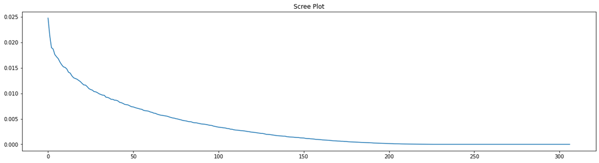

```python
plt.figure(figsize=(20,5))
plt.title("Scree Plot")
plt.plot(S_C**2 / np.sum(S_C**2))
```

#### Results

##### Unlabled Data

The following graph presents the results from the correspondence analysis. There are large outliers to the right and the bottom of the plot and a large mass at the center. Observations are considered outliers if either X or Y value is greater than 2. The analysis is subdivided to focus on the obtained regions and starts on the outside and increasingly narrow it down towards the center. Users are in green and hashtags are in blue.

```python
# seggragaion into different regions
is_user = [s.isnumeric() for s in res.index]
outliers = np.where(np.array(np.abs(res[0]) > 2) | np.array(np.abs(res[1]) > 2), 1, .1)
middle = np.where(np.array(np.abs(res[0]) <= 2) & np.array(np.abs(res[0]) > .5) | np.array(np.abs(res[1]) <= 2) & np.array(np.abs(res[1]) > .5), 1, .1)
middle_top = np.where(np.array(np.abs(res[0]) <= 2) & np.array(np.abs(res[0]) > .5) | np.array(res[1] <= 2) & np.array(res[1] > .5), 1, .1)
middle_bottom = np.where(np.array(np.abs(res[0]) <= 2) & np.array(np.abs(res[0]) > .5) | np.array(res[1] >= -2) & np.array(res[1] < -.5), 1, .1)
center = np.where(np.array(np.abs(res[0]) <= .5) & np.array(np.abs(res[1]) <= .5), 1, .1)
```

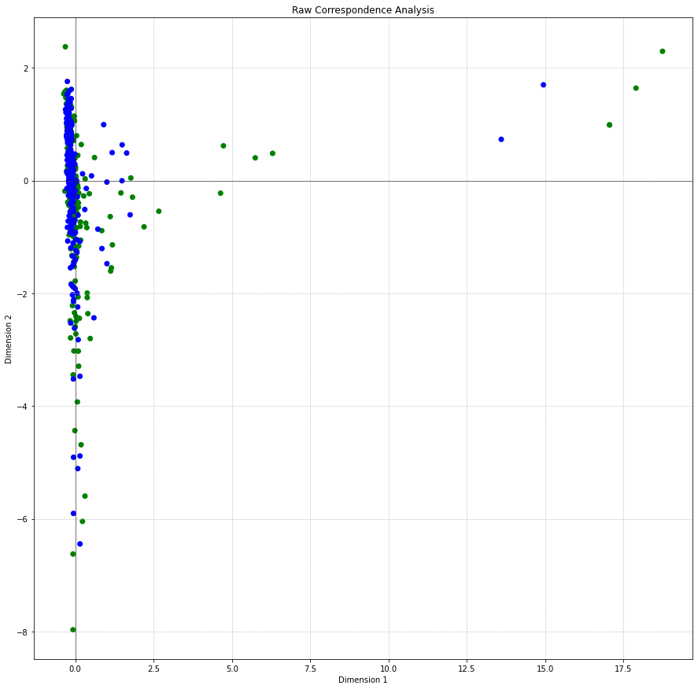

```python
plt.figure(figsize = [15, 15])
plt.title("Raw Correspondence Analysis")
plt.xlabel("Dimension 1")
plt.ylabel("Dimension 2")
plt.scatter(-res[0], res[1], color = np.where(is_user, 'g', 'b'))
# plt.scatter(standard_col_coord[0], standard_col_coord[1],alpha = outliers)
plt.axhline(0, color = 'black', linewidth = 0.5)
plt.axvline(0, color = 'black', linewidth = 0.5)
plt.grid(linestyle = '--', linewidth = 0.5)
```

##### Outliers

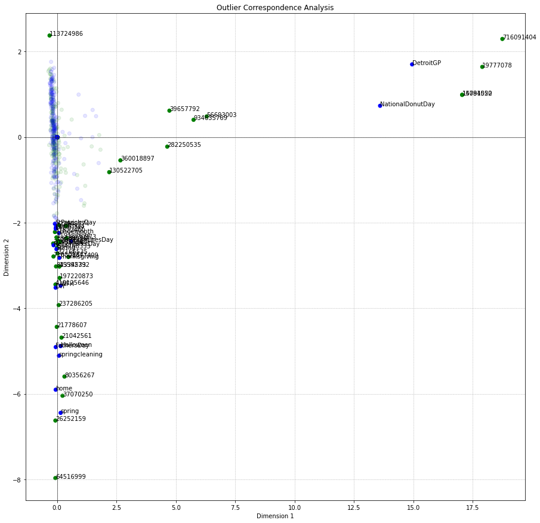

```python
plt.figure(figsize = [15, 15])
plt.title("Outlier Correspondence Analysis")
plt.xlabel("Dimension 1")
plt.ylabel("Dimension 2")
plt.scatter(-res[0], res[1],alpha = outliers, color = np.where(is_user, 'g', 'b'))
# plt.scatter(standard_col_coord[0], standard_col_coord[1],alpha = outliers)
plt.axhline(0, color = 'black', linewidth = 0.5)
plt.axvline(0, color = 'black', linewidth = 0.5)
plt.grid(linestyle = '--', linewidth = 0.5)
for i, txt in enumerate(res.index):
    if outliers[i] == 1:
        plt.annotate(txt, (-res.iloc[i,0], res.iloc[i,1]))
```

Moving towards the center there is a "loose" cluster of Dimension 1 values larger then 0.5. For positive Dimension 2 values the hashtags "retail", "news", "NowHiring" amongst others can be seen, while for negative Y values the hashtags "ad", "ChooseToChallenge" and "WorldSeries" amongst others can be found. Furthermore, there are two dense clusters around the center for positive and negative Dimension 2 values. In the following each of them will be analyzed separately.

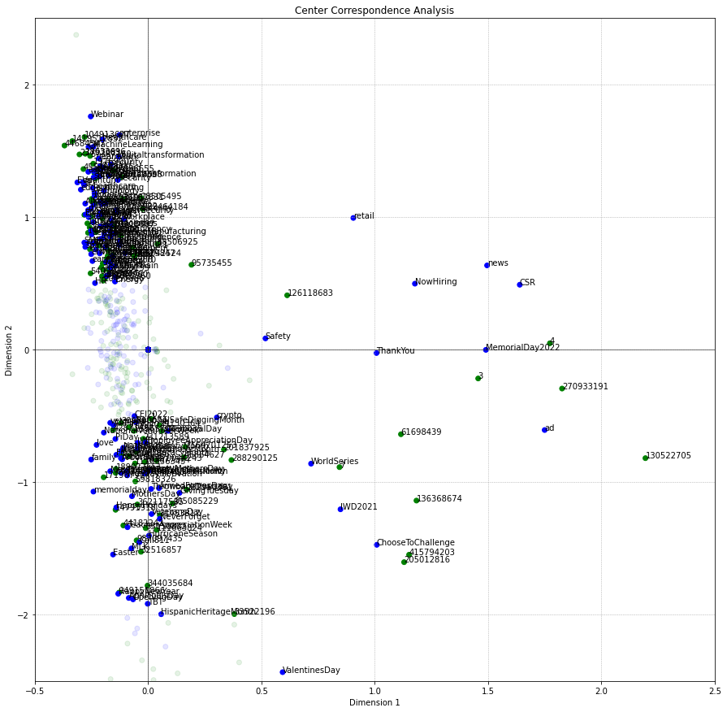

```python
plt.figure(figsize = [15, 15])
plt.title("Center Correspondence Analysis")
plt.xlabel("Dimension 1")
plt.ylabel("Dimension 2")
plt.xlim([-.5,2.5])
plt.ylim([-2.5,2.5])
plt.scatter(-res[0], res[1],alpha = middle, color = np.where(is_user, 'g', 'b'))
# plt.scatter(standard_col_coord[0], standard_col_coord[1],alpha = outliers)
plt.axhline(0, color = 'black', linewidth = 0.5)
plt.axvline(0, color = 'black', linewidth = 0.5)
plt.grid(linestyle = '--', linewidth = 0.5)
for i, txt in enumerate(res.index):
    if middle[i] == 1:
        plt.annotate(txt, (-res.iloc[i,0], res.iloc[i,1]))
```

The top cluster can be subdevided into three subclusters. The top subcluster, circled in red, shows corporations associated to hashtags such as "MachineLearning", "digitaltransformation", "quantum", "iot" (Internet of Things). In the blue circle, the middle cluster, are corporations associated with with hashtags such as "Robotics", "CyberSecurity", "military" and "automotive". In the third and bottom cluster circled in cyan, there is a less distinct group of corporations associated with hashtags "podcast", "supplychain", "energy" and "diversity". Overall, for positive Dimension 2 values in this cluster, corporations are associated to technology and innovation hashtags.

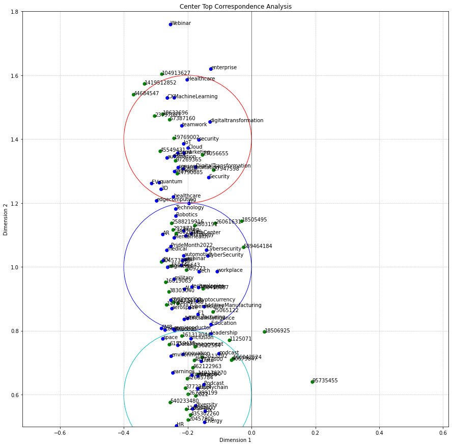

```python
fig, ax = plt.subplots(figsize=(15,15))
ax.set_title("Center Top Correspondence Analysis")
ax.set_xlabel("Dimension 1")
ax.set_ylabel("Dimension 2")
ax.set_xlim([-.4,.3])
ax.set_ylim([0.5,1.8])
ax.axhline(0, color = 'black', linewidth = 0.5)
ax.axvline(0, color = 'black', linewidth = 0.5)
ax.grid(linestyle = '--', linewidth = 0.5)
ax.scatter(-res[0], res[1],alpha = middle_top, color = np.where(is_user, 'g', 'b'))
cir1 = plt.Circle((-0.2, 1.4), 0.2, color='r',fill=False)
cir2 = plt.Circle((-0.2, 1.0), 0.2, color='b',fill=False)
cir3 = plt.Circle((-0.2, .6), 0.2, color='c',fill=False)
ax.set_aspect('equal', adjustable='datalim')
ax.add_patch(cir1)
ax.add_patch(cir2)
ax.add_patch(cir3)
for i, txt in enumerate(res.index):
    if middle_top[i] == 1:
        ax.annotate(txt, (-res.iloc[i,0], res.iloc[i,1]))
```

Regarding the lower dense cluster in the center, there is an overall pattern of corporations associated with hashtags relating to holidays.

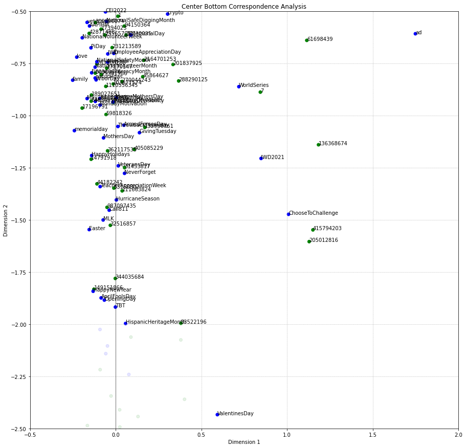

```python
plt.figure(figsize = [15, 15])
plt.title("Center Bottom Correspondence Analysis")
plt.xlabel("Dimension 1")
plt.ylabel("Dimension 2")
plt.xlim([-.5,2])
plt.ylim([-2.5,-.5])
plt.scatter(-res[0], res[1],alpha = middle_bottom, color = np.where(is_user, 'g', 'b'))
# plt.scatter(standard_col_coord[0], standard_col_coord[1],alpha = outliers)
plt.axhline(0, color = 'black', linewidth = 0.5)
plt.axvline(0, color = 'black', linewidth = 0.5)
plt.grid(linestyle = '--', linewidth = 0.5)
for i, txt in enumerate(res.index):
    if middle_bottom[i] == 1:
        plt.annotate(txt, (-res.iloc[i,0], res.iloc[i,1]))
```

Regarding the center part of the data, there is less of a distinction with regard to the difference between technology / innovation and holiday related hashtags. As an overall tendency, the plot confirmes the so far made observations of positive Dimension 2 values being associated with technology / innovation while negative Dimension 2 values are more associated with holidays. Although it has to be noted that there is a a less clear cut distinction between the two categories.

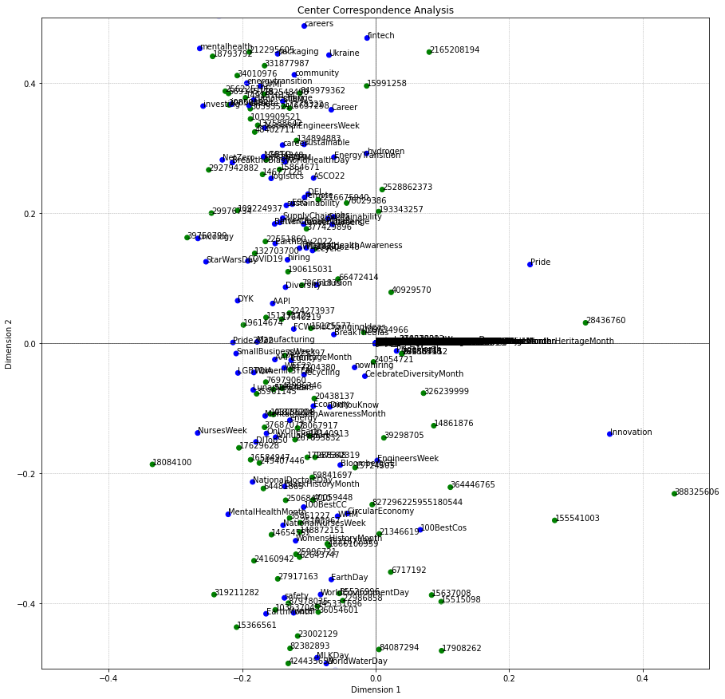

```python
plt.figure(figsize = [15, 15])
plt.title("Center Correspondence Analysis")
plt.xlabel("Dimension 1")
plt.ylabel("Dimension 2")
plt.xlim([-.5,.5])
plt.ylim([-.5,.5])
plt.scatter(-res[0], res[1],alpha = center, color = np.where(is_user, 'g', 'b'))
# plt.scatter(standard_col_coord[0], standard_col_coord[1],alpha = outliers)
plt.axhline(0, color = 'black', linewidth = 0.5)
plt.axvline(0, color = 'black', linewidth = 0.5)
plt.grid(linestyle = '--', linewidth = 0.5)
for i, txt in enumerate(res.index):
    if center[i] == 1:
        plt.annotate(txt, (-res.iloc[i,0], res.iloc[i,1]))
```

## Conclusio

The goal of this work is to analyse and draw inference of a corporation's network. The first step consisted of obtaining the corporate network data. Twitter does not provide information regarding whether or not an account belongs to a corporation. Thus a logistic regression model was used for this classification pupose. The model is able predict reasonably well and hence we used to model to classify a large amount of related user accounts into corporate and private accounts. Next, different methods to identify influential users were compared. A group of five most influential users could be identified. Next, several community detection algorithms were compared in order to find homogenous subgroups. The best method, spectral clustering according to the modularity measure, had almost all of the most influential users previously detected as the most influential user in each subgroup. Finally, the hashtags that each corporation posted were analyzed to look for similarities of interests among the corporations. Two main clusters of associations between corporation and hashtags emerged: one cluster is affiliated to hashtags relating to technology and innovation and another one which is associated with holidays.